# 201533892_홍기현

### 201533892-홍기현-기말고사

#### 목차

**1. 데이터 설명 및 보기**  
**2. 데이터 기초 분석 / 탐색**  
**3. 데이터 클린징**  
**4. 데이터 시각화**  
**5. 통계 또는 머신러닝**  
**6. 결론 및 본인 차별화 포인트**

### 1. 데이터 설명 및 보기

**데이터 출처 및 설명**

**countries of the world.csv 데이터**  
countries of the world.csv는 227개의 행과 20개의 열로 구성되어 있으며, 각각의 열은 인구, 지역, 면적, 영아 사망률 등에 대한 정보가 들어 있다. 해당 데이터의 원본은 미국 정부의 데이터로 구성되며, 이는 공개 도메인으로 무료로 제공된다. 이 데이터를 Kaggle의 데이터 세트에서 정리하였으며, 공공 데이터로 제공된다. 본 데이터의 다양한 열을 활용하여 국가별 GDP를 예측 하는 머신러닝 모델을 구축하거나, 출생률과 사망률 데이터를 통한 인구 변화 동향을 예측하는데 주로 사용된다.  
원본데이터 출처  
https://www.cia.gov/library/publications/the-world-factbook/docs/faqs.html  
countries of the world 데이터 출처  
https://www.kaggle.com/fernandol/countries-of-the-world

**List of Countries by number of Internet Users - Sheet1.csv 데이터**  
List of Countries by number of Internet Users - Sheet1.csv 데이터는 215개의 행과 6개의 열로 구성되어 있다. 본 데이터는 2018년 인터넷 사용자 수에 따른 국가 목록 데이터이다. 원본 데이터 수집은 Wikipedia에서 하였으며, 이를 csv 파일로 변환한 Kaggle의 오픈 데이터이다. 데이터에는 나라 이름, 인터넷 사용자 수, 인구 수, 인터넷 사용자 비율 등의 열이 있다. 본 데이터를 활용하여 인터넷을 사용하지 않은 인구가 많은 나라를 시장 타깃으로 삼는 데이터 분석이나, 인터넷 사용자 수를 시각화하는 분석에 사용되었다.  
원본 데이터 출처  
https://en.wikipedia.org/wiki/List_of_countries_by_number_of_Internet_users  
List of Countries by number of Internet Users - Sheet1 데이터 출처  
https://www.kaggle.com/tanuprabhu/list-of-countries-by-number-of-internet-users

**Life_expectancy_dataset.csv 데이터**  
Life_expectancy_dataset.csv 데이터는 223개의 행과 6개의 열로 구성되어 있다. 본 데이터는 국가별 남성의 기대수명과 여성의 기대수명, 그리고 종합적인 기대수명에 대한 정보가 들어있다. 해당 데이터의 원본은 Wikipedia의 List of copuntries by life expectancy 검색을 통해 얻을 수 있으며, 이 데이터를 csv 파일로 변환하여 Kaggle의 오픈 데이터로 제공한다. 기대 수명 이외로 대륙 단위의 지역 구분 열이 존재하며, 이를 통하여 대륙별 기대 수명을 구할 수 있다. 본 데이터를 이용하여 특정 나라의 남성이 여성에 비해 유난히 기대 수명이 짧은 이유를 분석하는데 본 데이터가 활용 되었으며, 나라 이름으로 다른 데이터와 병합 하여 사용하는 경우가 많다.  
원본 데이터 출처  
https://en.wikipedia.org/wiki/List_of_countries_by_life_expectancy#List_by_the_CIA_.282016.29  
Life_expectancy_dataset 데이터 출처  
https://www.kaggle.com/amansaxena/lifeexpectancy

**분석 내용 설명**

본 데이터 분석에서는 인터넷 사용률이 얼마나 의료 인프라에 영향을 주어 기대수명을 증가 시키고, 영아 사망률을 낮출 수 있는지 알아본다. 이를 위하여 국가의 다양한 정보가 담겨있고 GDP와 1000명의 출생 당 영아 사망률이 담겨 있는 countries of the world 데이터와 각 나라별 인터넷 사용률이 있는 List of Countries by number of Internet Users 데이터, 그리고 각 나라별 기대 수명이 있는 Life_expectancy_dataset을 나라 이름으로 병합하여 사용한다. GDP 증가에 따라서 의료 인프라에 영향을 줄 것으로 판단되므로, GDP와 인터넷 사용률의 상관 관계를 분석하며, GDP 증가에 따른 의료 인프라, 인터넷 사용률에 따른 의료 인프라 경향을 각각 분석한다.

### 2. 데이터 기초 분석 / 탐색

```python
import pandas as pd
import matplotlib as mpl
import matplotlib.pylab as plt
import seaborn as sns
import numpy as np
import statsmodels.api as sm
import missingno as msno
from scipy import stats
```

```python
file_path = 'C:/data/finalTest/countries of the world.csv'
world = pd.read_csv(file_path, engine='python')
file_path = 'C:/data/finalTest/List of Countries by number of Internet Users - Sheet1.csv'
internet = pd.read_csv(file_path, engine='python')
file_path = 'C:/data/finalTest/Life_expectancy_dataset.csv'
life = pd.read_csv(file_path, engine='python')
```

```python
world_copy = world.copy()
world_copy.to_csv('C:/data/finalTest/world_copy.csv')
internet_copy = internet.copy()
internet_copy.to_csv('C:/data/finalTest/internet_copy.csv')
life_copy = life.copy()
life_copy.to_csv('C:/data/finalTest/life_copy.csv')
```

- 원본 데이터가 손상될 경우, 다시 원본 데이터를 얻지 못할 경우를 대비하여 원본 데이터는 보존되어야 한다. 따라서, copy() 메소드와 to_csv() 메소드를 통하여 원본 데이터를 보존한다.

```python
world.info()
world.head(3)
```

```
<class 'pandas.core.frame.DataFrame'>
RangeIndex: 227 entries, 0 to 226
Data columns (total 20 columns):
 #   Column                              Non-Null Count  Dtype
---  ------                              --------------  -----
 0   Country                             227 non-null    object
 1   Region                              227 non-null    object
 2   Population                          227 non-null    int64
 3   Area (sq. mi.)                      227 non-null    int64
 4   Pop. Density (per sq. mi.)          227 non-null    float64
 5   Coastline (coast/area ratio)        227 non-null    float64
 6   Net migration                       224 non-null    float64
 7   Infant mortality (per 1000 births)  224 non-null    float64
 8   GDP ($ per capita)                  226 non-null    float64
 9   Literacy (%)                        209 non-null    float64
 10  Phones (per 1000)                   223 non-null    float64
 11  Arable (%)                          225 non-null    float64
 12  Crops (%)                           225 non-null    float64
 13  Other (%)                           225 non-null    float64
 14  Climate                             205 non-null    float64
 15  Birthrate                           224 non-null    float64
 16  Deathrate                           223 non-null    float64
 17  Agriculture                         212 non-null    float64
 18  Industry                            211 non-null    float64
 19  Service                             212 non-null    float64
dtypes: float64(16), int64(2), object(2)
memory usage: 35.6+ KB
```

|  | Country | Region | Population | Area (sq. mi.) | Pop. Density (per sq. mi.) | Coastline (coast/area ratio) | Net migration | Infant mortality (per 1000 births) | GDP ($ per capita) | Literacy (%) | Phones (per 1000) | Arable (%) | Crops (%) | Other (%) | Climate | Birthrate | Deathrate | Agriculture | Industry | Service |
| --- | --- | --- | --- | --- | --- | --- | --- | --- | --- | --- | --- | --- | --- | --- | --- | --- | --- | --- | --- | --- |
| 0 | Afghanistan | ASIA (EX. NEAR EAST) | 31056997 | 647500 | 48.0 | 0.00 | 23.06 | 163.07 | 700.0 | 36.0 | 3.2 | 12.13 | 0.22 | 87.65 | 1.0 | 46.60 | 20.34 | 0.380 | 0.240 | 0.380 |
| 1 | Albania | EASTERN EUROPE | 3581655 | 28748 | 124.6 | 1.26 | -4.93 | 21.52 | 4500.0 | 86.5 | 71.2 | 21.09 | 4.42 | 74.49 | 3.0 | 15.11 | 5.22 | 0.232 | 0.188 | 0.579 |
| 2 | Algeria | NORTHERN AFRICA | 32930091 | 2381740 | 13.8 | 0.04 | -0.39 | 31.00 | 6000.0 | 70.0 | 78.1 | 3.22 | 0.25 | 96.53 | 1.0 | 17.14 | 4.61 | 0.101 | 0.600 | 0.298 |

world 데이터의 변수명과 이에 대한 설명, 타입은 다음과 같다.

| 변수명 | 설명 | 타입 |
| --- | --- | --- |
| Country | 나라 이름 | 기본키, 범주형 |
| Region | 해당 나라가 속한 지역 이름 | 범주형 |
| Population | 인구수 | 연속형 |
| Area (sq. mi.) | 면적 | 연속형 |
| Pop. Density (per sq. mi.) | 인구밀도 | 연속형 |
| Coastline (coast/area ratio) | 면적을 해안선 길이로 나눈 비율 | 연속형 |
| Net migration | 연간 이민을 가는 사람과 이민을 오는 사람의 비율 | 연속형 |
| Infant mortality (per 1000 births) | 1000회의 출산 당 영아가 사망하는 영아사망률 | 연속형 |
| GDP ($ per capita) | 1인당 GDP | 연속형 |
| Literacy (%) | 문해력 비율 | 연속형 |
| Phones (per 1000) | 1000명당 휴대폰 보급률 | 연속형 |
| Arable (%) | 경작지 비율 | 연속형 |
| Crops (%) | 농작지 비율 | 연속형 |
| Other (%) | 그외 지역 비율 | 연속형 |
| Climate | 기후 | 범주형 |
| Birthrate | 연간 1000명당 출생자 비율 | 연속형 |
| Deathrate | 연간 1000명당 사망자 비율 | 연속형 |
| Agriculture | 농업 종사자 비율 | 연속형 |
| Industry | 산업 종사자 비율 | 연속형 |
| Service | 서비스 종사자 비율 | 연속형 |

world 데이터에는 추후에 데이터의 병합, 데이터 전처리, 그리고 데이터의 시각화 할때 적합하지 않은 변수명이 존재한다. **괄호나 띄어쓰기는 데이터 분석을 위한 메소드 사용시에 오류가 발생할 수 있으며, 데이터 병합을 위한 merge 메소드 사용시에 같은 데이터라도 열의 이름이 상이하여 데이터 병합이 잘 이루어지지 않을 수도 있다. 이를 방지하고 편한 데이터 분석을 위해 모든 열을 한글로 변경하며, 띄어쓰기와 괄호를 전부 제거한다**

```python
world.rename(columns={'Country':'나라명', 'Region':'지역', 'Population':'인구', 'Area (sq. mi.)':'면적', 'Pop. Density (per sq. mi.)':'인구밀도', 'Coastline (coast/area ratio)':'해안선비율', 'Net migration':'순이민율', 'Infant mortality (per 1000 births)':'영아사망률', 'GDP ($ per capita)':'GDP', 'Literacy (%)':'문해력', 'Phones (per 1000)':'휴대폰보급률', 'Arable (%)':'경작지', 'Crops (%)':'농작지', 'Other (%)':'그외지역', 'Climate':'기후', 'Birthrate':'출생율', 'Deathrate':'사망률', 'Agriculture':'농업종사자', 'Industry':'산업종사자', 'Service':'서비스종사자'}, inplace=True)
```

**본 분석에 이용하지 않을 변수를 미리 제거하여 데이터 병합 이후에도 데이터 분석에 적절한 양의 데이터를 유지하도록 한다.**

```python
world = world.drop(['면적', '해안선비율', '순이민율', '문해력', '경작지', '농작지', '그외지역', '기후', '농업종사자', '산업종사자', '서비스종사자'], axis=1)
```

범주형 변수에 해당하는 지역 변수에는 데이터 열의 수를 맞추기 위해 많은 띄어쓰기와 해석하기 힘든 타입으로 저장되어 있다. **이 지역 변수의 값을 알맞은 한글 데이터로 변경하여 데이터 분석에 용이함과 동시에 같은 대륙이지만 나뉘어져 있는 데이터를 통합하여 지역 변수의 그룹의 수를 줄인다.**

```python
world.loc[world['지역'] == "SUB-SAHARAN AFRICA                 ", '지역'] = '아프리카'
world.loc[world['지역'] == "LATIN AMER. & CARIB    ", '지역'] = '아메리카'
world.loc[world['지역'] == "WESTERN EUROPE                     ", '지역'] = '유럽'
world.loc[world['지역'] == "ASIA (EX. NEAR EAST)         ", '지역'] = '아시아'
world.loc[world['지역'] == "OCEANIA                            ", '지역'] = '오세아니아'
world.loc[world['지역'] == "NEAR EAST                          ", '지역'] = '중동'
world.loc[world['지역'] == "EASTERN EUROPE                     ", '지역'] = '유럽'
world.loc[world['지역'] == "C.W. OF IND. STATES ", '지역'] = '독립국가'
world.loc[world['지역'] == "NORTHERN AFRICA                    ", '지역'] = '아프리카'
world.loc[world['지역'] == "NORTHERN AMERICA                   ", '지역'] = '아메리카'
world.loc[world['지역'] == "BALTICS                            ", '지역'] = '유럽'
```

나라별 인터넷 사용률 데이터를 얻기 위한 internet 데이터와 나라별 기대수명을 얻기 위한 life 데이터의 기초 분석 및 탐색을 실시한다.

- internet 데이터는 해당 나라와 그 나라에 대한 데이터가 포함된다. 데이터 병합을 위해 나라 이름을 나라명으로 통일하며, 그 나라 국민의 인터넷 사용 percemtage 데이터를 제외한 모든 데이터는 본 분석에 사용하지 않으므로 제거한다.
- life 데이터는 해당 나라와 그 나라에 대한 데이터가 포함된다. 데이터 병합을 위해 나라 이름을 나라명으로 통일하며, 그 나라 남녀통합 기대수명 데이터를 제외한 모든 데이터는 본 분석에 사용하지 않으므로 제거한다.

```python
internet.info()
internet.head(3)
```

```
<class 'pandas.core.frame.DataFrame'>
RangeIndex: 215 entries, 0 to 214
Data columns (total 6 columns):
 #   Column           Non-Null Count  Dtype
---  ------           --------------  -----
 0   Country or Area  215 non-null    object
 1   Internet Users   215 non-null    object
 2   Population       215 non-null    object
 3   Rank             215 non-null    int64
 4   Percentage       215 non-null    float64
 5   Rank.1           215 non-null    object
dtypes: float64(1), int64(1), object(4)
memory usage: 10.2+ KB
```

|  | Country or Area | Internet Users | Population | Rank | Percentage | Rank.1 |
| --- | --- | --- | --- | --- | --- | --- |
| 0 | China | 765,367,947 | 1,409,517,397 | 1 | 0.5430 | 116 |
| 1 | India | 461,347,554 | 1,339,180,127 | 2 | 0.3445 | 145 |
| 2 | United States | 244,090,854 | 324,459,463 | 3 | 0.7523 | 68 |

| 변수명 | 설명 | 타입 |
| --- | --- | --- |
| Country or Area | 나라이름 | 기본키, 범주형 |
| Internet Users | 인터넷 사용 인구 수 | 연속형 |
| Population | 인구 수 | 연속형 |
| Rank | 인구 수 순위 | 연속형 |
| Percentage | 인터넷 사용자 비율 | 연속형 |
| Rank.1 | 인터넷 사용자 비율 순위 | 연속형 |

```python
internet.rename(columns={'Country or Area':'나라명', 'Internet Users':'인터넷사용자수', 'Population':'인구', 'Rank':'인구별국가순위', 'Percentage':'인터넷사용자비율', 'Rank.1':'인터넷사용자순위'}, inplace=True)
```

```python
internet = internet.drop(['인터넷사용자수', '인구', '인구별국가순위'], axis=1)
```

```python
life.info()
life.head(3)
```

```
<class 'pandas.core.frame.DataFrame'>
RangeIndex: 223 entries, 0 to 222
Data columns (total 6 columns):
 #   Column        Non-Null Count  Dtype
---  ------        --------------  -----
 0   Rank          223 non-null    int64
 1   Country       223 non-null    object
 2   Overall Life  223 non-null    float64
 3   Male Life     223 non-null    float64
 4   Female Life   223 non-null    float64
 5   Continent     223 non-null    object
dtypes: float64(3), int64(1), object(2)
memory usage: 10.6+ KB
```

|  | Rank | Country | Overall Life | Male Life | Female Life | Continent |
| --- | --- | --- | --- | --- | --- | --- |
| 0 | 1 | Monaco | 89.5 | 85.6 | 93.5 | Europe |
| 1 | 2 | Japan | 85.0 | 81.7 | 88.5 | Asia |
| 2 | 3 | Singapore | 85.0 | 82.3 | 87.8 | Asia |

| 변수명 | 설명 | 타입 |
| --- | --- | --- |
| Rank | 기대수명 순위 | 기본키, 연속형 |
| Country | 나라이름 | 범주형 |
| Overall Life | 기대수명 | 연속형 |
| Male Life | 남성 기대수명 | 연속형 |
| Female Life | 여성 기대수명 | 연속형 |
| Continent | 지역 | 범주형 |

```python
life.rename(columns={'Rank':'기대수명순위', 'Country':'나라명', 'Overall Life':'기대수명', 'Male Life':'남성기대수명', 'Female Life':'여성기대수명', 'Continent':'지역'}, inplace=True)
```

```python
life = life.drop(['기대수명순위', '남성기대수명', '여성기대수명', '지역'], axis=1)
```

**본 데이터 분석을 위해 world 데이터, 나라별 인터넷 사용률을 가진 internet 데이터, 나라별 기대수명을 가진 life 데이터를 병합한다.**

```python
world = pd.merge(world, internet, on='나라명')
world = pd.merge(world, life, on='나라명')
```

**병합된 데이터는 추후에 데이터 클린징이나, 시각화 이후에 소실될 수 있기 때문에 이를 대비하기 위하여 to_csv() 메소드를 통하여 데이터를 보존한다. 이때 변수 명과 지역 변수의 데이터는 한글로 변경하였기 때문에 인코딩 방식을 'utf-8-sig'를 주어 한글이 깨지지 않도록 한다.**

```python
world_merge_copy = world.copy()
world_merge_copy.to_csv('C:/data/finalTest/world_merge_copy.csv', encoding='utf-8-sig')
```

### 3. 데이터 클린징

데이터 클린징은 이상 데이터, 결측 데이터, 중복 데이터를 제거하거나 대체하는 과정이다. 본 데이터 분석에서 데이터 클린징은 이상치부터 처리하기로 한다. **만약 결측치를 먼저 처리한다고 가정하면, 결측값을 평균값이나 중위수로 대체 시 이상치로 인하여 의도하지 않은 값으로 대체될 가능성이 있다고 판단하였기 때문이다.**

**이상치 제거**

```python
sns.set_palette('pastel')
plt.rc('font', family='Malgun Gothic')
```

```python
world.describe()
```

|  | 인구 | 인구밀도 | 영아사망률 | GDP | 휴대폰보급률 | 출생율 | 사망률 | 인터넷사용자비율 | 기대수명 |
| --- | --- | --- | --- | --- | --- | --- | --- | --- | --- |
| count | 1.830000e+02 | 183.000000 | 182.000000 | 183.000000 | 181.000000 | 181.000000 | 181.000000 | 183.000000 | 183.000000 |
| mean | 2.686068e+07 | 288.059563 | 37.420275 | 9825.683060 | 216.731492 | 22.457182 | 9.644862 | 0.546824 | 72.212568 |
| std | 8.946556e+07 | 1325.903948 | 36.784829 | 10503.120753 | 225.495477 | 11.342088 | 5.226259 | 0.284277 | 8.608104 |
| min | 9.439000e+03 | 1.800000 | 2.290000 | 500.000000 | 1.300000 | 8.250000 | 2.410000 | 0.013100 | 50.200000 |
| 25% | 1.282580e+06 | 27.100000 | 8.290000 | 1900.000000 | 31.800000 | 12.560000 | 6.170000 | 0.297150 | 66.850000 |
| 50% | 6.506464e+06 | 66.900000 | 22.740000 | 5100.000000 | 137.900000 | 20.340000 | 8.250000 | 0.572700 | 74.700000 |
| 75% | 2.024316e+07 | 163.350000 | 61.492500 | 15700.000000 | 333.800000 | 30.010000 | 11.550000 | 0.795350 | 78.450000 |
| max | 1.095352e+09 | 16271.500000 | 191.190000 | 55100.000000 | 1035.600000 | 50.730000 | 29.740000 | 0.988700 | 89.500000 |

이상치를 제거하기 위하여 describe() 메소드를 통하여 각 변수의 min, max 값을 중심으로 분석을 실시한다.

- **다른 실제 자료를 통하여 이상치의 유무를 쉽게 파악할 수 있는 인구, 인구밀도, GDP 데이터는 오름차순, 내림차순 출력을 통하여 실제 데이터와 비교 후 판단에 따라 이상치를 제거한다.**
- 영아 사망률, 휴대폰 보급률, 출생율, 사망률, 인터넷사용자비율, 기대수명 데이터는 boxplot을 통한 시각화를 통하여 판단 후 이상치를 제거한다.

```python
world.sort_values(by=['GDP'], axis=0, ascending=False).head(2)
```

|  | 나라명 | 지역 | 인구 | 인구밀도 | 영아사망률 | GDP | 휴대폰보급률 | 출생율 | 사망률 | 인터넷사용자비율 | 인터넷사용자순위 | 기대수명 |
| --- | --- | --- | --- | --- | --- | --- | --- | --- | --- | --- | --- | --- |
| 95 | Luxembourg | 유럽 | 474413 | 183.5 | 4.81 | 55100.0 | 515.4 | 11.94 | 8.41 | 0.9783 | 6 | 82.3 |
| 121 | Norway | 유럽 | 4610820 | 14.2 | 3.70 | 37800.0 | 461.7 | 11.46 | 9.40 | 0.9651 | 11 | 81.8 |

```python
world.sort_values(by=['GDP'], axis=0, ascending=True).head(2)
```

|  | 나라명 | 지역 | 인구 | 인구밀도 | 영아사망률 | GDP | 휴대폰보급률 | 출생율 | 사망률 | 인터넷사용자비율 | 인터넷사용자순위 | 기대수명 |
| --- | --- | --- | --- | --- | --- | --- | --- | --- | --- | --- | --- | --- |
| 144 | Sierra Leone | 아프리카 | 6005250 | 83.7 | 143.64 | 500.0 | 4.0 | 45.76 | 23.03 | 0.1324 | 189 | 58.2 |
| 149 | Somalia | 아프리카 | 8863338 | 13.9 | 116.70 | 500.0 | 11.3 | 45.13 | 16.63 | 0.0200 | 208 | 52.4 |

GDP 변수의 이상치를 제거하기 위해 세계에서 가장 GDP가 높은 2개의 나라와 GDP가 낮은 2개의 나라를 출력하였다. 실제 데이터에 의하면 연도의 차이가 있어 정확히 일치하지는 않지만, 룩셈부르크가 GDP가 높으며, 노르웨이가 뒤를 잇는 것을 볼 수 있다. 또한 GDP가 가장 낮은 나라는 해당 나라를 나라로 판단하는 기준이 상이하여 정확히 일치하지는 않지만 소밀리아가 498 달러로 해당 데이터인 500 달러와 거의 동일하다고 볼 수 있다.

- 1인당 GDP 순위 출처 https://ko.wikipedia.org/wiki/%EC%9D%BC%EC%9D%B8%EB%8B%B9_%EB%AA%85%EB%AA%A9_%EA%B5%AD%EB%82%B4_%EC%B4%9D%EC%83%9D%EC%82%B0%EC%88%9C_%EB%82%98%EB%9D%BC_%EB%AA%A9%EB%A1%9D
- 나라별 인구 수 출처 https://ko.wikipedia.org/wiki/%EC%9D%B8%EA%B5%AC%EC%88%9C_%EB%82%98%EB%9D%BC_%EB%AA%A9%EB%A1%9D
- 나라별 인구 밀도 출처 https://ko.wikipedia.org/wiki/%EC%9D%B8%EA%B5%AC_%EB%B0%80%EB%8F%84%EC%88%9C_%EB%82%98%EB%9D%BC_%EB%AA%A9%EB%A1%9D

이와 마찬가지로 인구 수, 인구밀도 데이터를 분석한 결과 이상치를 다음과 같이 판단한다.

- 본 데이터 분석에서 사용하는 인구, 인구밀도, GDP 데이터 중 50000 달러가 넘는 룩셈 부르크의 GDP는 2위와의 격차가 1.5배 정도 발생한다. 이는 본 데이터 분석에서 일반화되기 어렵다고 판단하여 제거하도록 한다.

```python
world = world[(world['GDP'] <= 50000)]
```

인구, 인구밀도, GDP를 제외한 데이터의 이상치 제거는 boxplot을 통하여 실시한다.

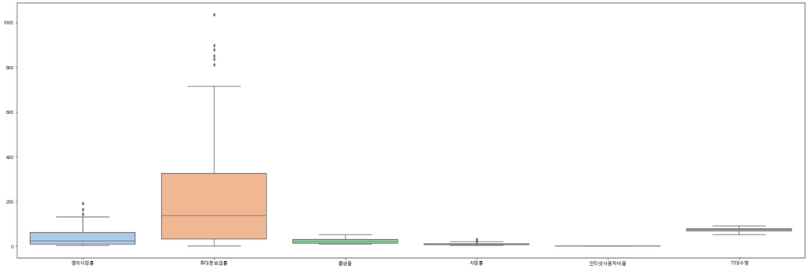

```python
plt.figure(figsize=(30,10))
sns.boxplot(data=world.drop(['인구', 'GDP', '인구밀도'], axis=1) ,width=0.8)
```

```python
world = world[(world['휴대폰보급률'] <= 1000)]
```

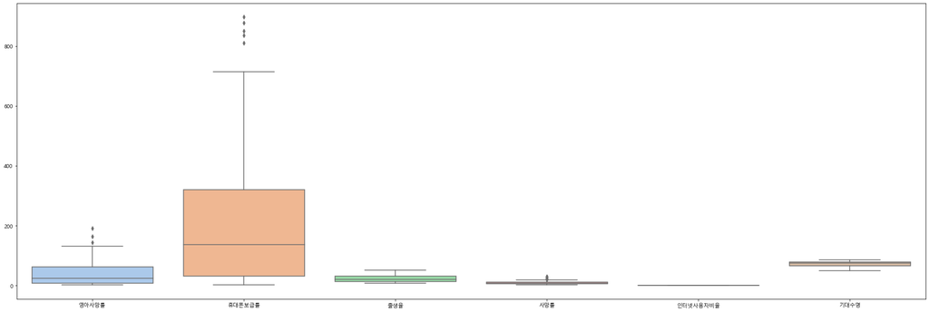

```python
plt.figure(figsize=(30,10))
sns.boxplot(data=world.drop(['인구', 'GDP', '인구밀도'], axis=1) ,width=0.8)
```

휴대폰 보급률 데이터는 1000명 당 휴대폰 개수를 나타내는 변수이다. 해당 변수를 보면 1000이 넘는 값이 존재한다. 이는 1명의 국민이 1대 이상의 휴대폰을 소유한다는 의미이다. 실제로 해당 값이 가능할수도 있지만, 본 데이터 분석에서 일반화되기 어렵다고 판단되므로 제거하도록 한다.

**describe() 메소드나 boxplot() 시각화는 연속형 변수의 이상치만을 볼 수 있다는 단점이 존재한다. 만약 범주형 범주에서 오타와 같은 실수가 발생할 경우 결측치 데이터가 아니기 때문에 결측치 제거에서도 관측이 안되는 오류가 발생할 수 있다. 따라서 이상치 처리에서 이에 대한 처리가 필요하다. 이를 value_counts() 메소드를 통하여 이상치를 관측한다.**

```python
world['지역'].value_counts()
```

```
아프리카     46
유럽       36
아메리카     36
아시아      21
오세아니아    15
중동       13
독립국가     12
Name: 지역, dtype: int64
```

world 데이터에는 나라명을 제외한 범주형 데이터는 지역를 나타내는 변수 하나이다. 이를 value_counts()로 관측한 결과 이상 데이터는 존재하지 않는 것으로 판단된다.

**결측치 제거**

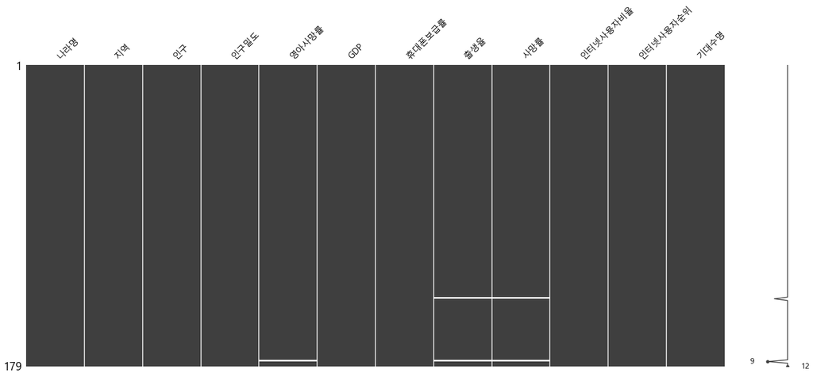

```python
msno.matrix(world)
```

```python
world = world.dropna()
```

```python
world.isnull().sum()
```

```
나라명         0
지역          0
인구          0
인구밀도        0
영아사망률       0
GDP         0
휴대폰보급률      0
출생율         0
사망률         0
인터넷사용자비율    0
인터넷사용자순위    0
기대수명        0
dtype: int64
```

world 데이터에 존재하는 결측 데이터를 확인하기 위해 결측치 시각화 도구를 지원하는 missingno 패키지를 사용하여 결측치를 시각화한다. 시각화하여 분석결과 다음과 같다.

- 영아 사망률에서 1개의 결측 데이터가 관측된다.
- 출생률과 사망률에서 2개씩의 결측 데이터가 관측된다.
- 출생률과 사망률 데이터는 같은 행에서 결측치가 발생한 것으로 보인다.
- 영아 사망률 데이터는 출생률, 사망률 결측 데이터가 발생한 행에서 결측치가 발생한 것으로 보인다.

따라서 dropna() 메소드를 통하여 결측치가 발생한 행을 제거한다고 하더라도 2개의 행만 제거되며, 이는 수많은 나라 데이터에서 제거되어도 데이터 분석에 지장이 없을 것이라 판단된다. dropna() 메소드를 통하여 결측치를 제거한 후 isnull().sum() 메소드를 통하여 결측치가 잘 제거되었는지 확인한다.

**중복값 제거**

중복 값은 데이터 무결성의 원칙에 따라 제거하도록한다

```python
world.duplicated()
world.drop_duplicates().head(3)
```

|  | 나라명 | 지역 | 인구 | 인구밀도 | 영아사망률 | GDP | 휴대폰보급률 | 출생율 | 사망률 | 인터넷사용자비율 | 인터넷사용자순위 | 기대수명 |
| --- | --- | --- | --- | --- | --- | --- | --- | --- | --- | --- | --- | --- |
| 0 | Afghanistan | 아시아 | 31056997 | 48.0 | 163.07 | 700.0 | 3.2 | 46.60 | 20.34 | 0.1145 | 194 | 51.3 |
| 1 | Albania | 유럽 | 3581655 | 124.6 | 21.52 | 4500.0 | 71.2 | 15.11 | 5.22 | 0.7185 | 73 | 78.3 |
| 2 | Algeria | 아프리카 | 32930091 | 13.8 | 31.00 | 6000.0 | 78.1 | 17.14 | 4.61 | 0.4769 | 130 | 76.8 |

### 4. 데이터 시각화

본 데이터 분석에서는 해당 나라의 인터넷 사용률과 같은 인터넷 인프라가 의료 서비스 제공에 있어서 얼마나 영향을 주는지에 대한 분석을 목표로 한다. 이를 위해서 의료 인프라에 영향을 줄 수 있는 또 다른 지표 중 하나인 GDP와의 상관 분석을 먼저 실시해본다.

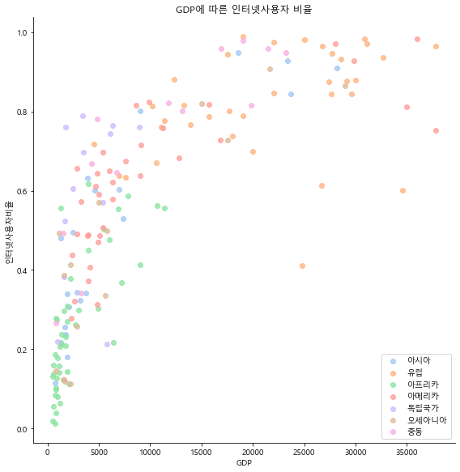

```python
sns.lmplot(size=8, x="GDP", y="인터넷사용자비율", data=world, fit_reg=False, hue='지역', legend=False)
plt.legend(loc='lower right')
plt.gca().set_title("GDP에 따른 인터넷사용자 비율")
```

GDP와 인터넷 사용자 비율의 상관 분석을 통하여 두 변수의 관계를 시각화하였다. 이를 통하여 다음과 같은 정보를 알 수 있다.

GDP와 인터넷 사용률을 상관 분석한 결과에서 GDP가 증가할 수록 인터넷 사용률도 증가하는 경향을 보인다. 이를 확실히 보기 위하여 GDP와 인터넷 사용률을 그룹화하여 해당 나라의 GDP 그룹이 정해졌을 때, 어떠한 인터넷 사용률 그룹에 속할 확률이 높은지 빈도 분석을 실시한다.

**describe()를 통하여 분석한 결과, 그룹을 min-25%, 25%-50%, 50%-75%, 75%-max로 4개의 범주로 구분한다. 이를 통하여 각 범주마다 같은 수의 데이터가 그룹화된다.**

```python
world.GDP.describe()
```

```
count      177.000000
mean      9533.898305
std       9969.497973
min        500.000000
25%       1900.000000
50%       5100.000000
75%      15000.000000
max      37800.000000
Name: GDP, dtype: float64
```

```python
bins = [0, 1900, 5100, 15000, 40000]

world_gdp = pd.cut(world['GDP'], bins, labels=['G1저소득', 'G2중소득', 'G3고소득', 'G4초고소득'])
world['GDP그룹'] = world_gdp
```

```python
world.인터넷사용자비율.describe()
```

```
count    177.000000
mean       0.542228
std        0.282411
min        0.013100
25%        0.296400
50%        0.571200
75%        0.788900
max        0.988700
Name: 인터넷사용자비율, dtype: float64
```

```python
bins = [0, 0.2964, 0.5712, 0.7889, 0.9887]

world_internet = pd.cut(world['인터넷사용자비율'], bins, labels=['G1낮음', 'G2보통', 'G3중간', 'G4높음'])
world['인터넷사용자비율그룹'] = world_internet
```

```python
gdp_group = world.groupby(['GDP그룹'])
pivot = gdp_group.인터넷사용자비율그룹.value_counts(normalize=True, sort=False).unstack().sort_index(axis=1)
```

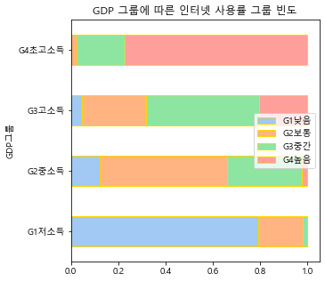

```python
plt.rcParams["figure.figsize"] = (5, 5)
pivot.plot(kind='barh', stacked=True, edgecolor='gold')
plt.legend(loc='right')
plt.gca().set_title("GDP 그룹에 따른 인터넷 사용률 그룹 빈도")
```

GDP 그룹별로 해당 나라의 인터넷 사용률이 속한 그룹을 빈도분석을 통하여 시각화를 했다.

- GDP가 매우 낮은 저소득 그룹에서 대부분의 나라가 인터넷 사용률 낮음 그룹에 속한다.
- GDP가 매우 높은 초고소득 그룹에서 대부분의 나라는 인터넷 보급률이 매우 높은 그룹에 속한다.
- GDP가 중위소득을 차지하는 그룹에서는 인터넷 보급률도 보통 그룹에 속할 경우가 가장 많다.
- GDP가 고소득 그룹인 경우에도 인터넷 보급률이 중간인 경우가 가장 많다.

GDP와 인터넷 사용률을 데이터 개수를 기준으로 4개의 범주형으로 구분하였을 때, GDP와 인터넷 사용률 그룹 수준이 비슷할 경우가 가장 많은 것을 알 수 있다. 이를 통하여 GDP와 인터넷 사용률이 연관이 있다는 것을 알 수 있다.

그렇다면, 같이 증가하는 경향을 보이는 GDP와 인터넷 사용률 중에서 어떠한 변수가 그 나라의 기대 수명이나 영아 사망률과 같은 의료 인프라에 더 상관이 있는지 알아본다. 이를 위하여 GDP와 기대수명의 관계를 시각화하며, 마찬가지로 인터넷 사용률과 기대수명을 시각화한다.

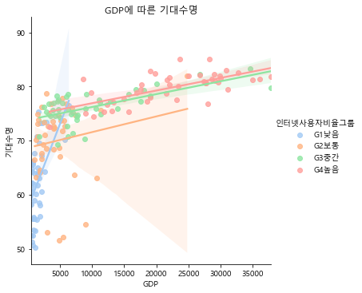

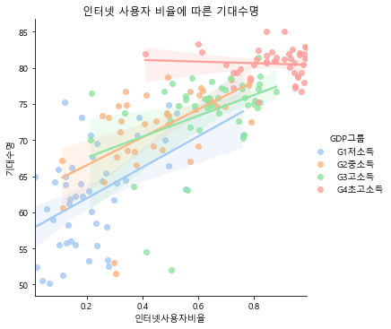

```python
sns.lmplot('GDP', '기대수명', hue='인터넷사용자비율그룹', data=world)
plt.title("GDP에 따른 기대수명")

sns.lmplot('인터넷사용자비율', '기대수명', hue='GDP그룹', data=world)
plt.title("인터넷 사용자 비율에 따른 기대수명")
```

인터넷 사용자 비율이 낮은 그룹에서는 GDP가 증가함에 따라 기대 수명이 급격하게 증가하는 경향을 보인다. 그리고 인터넷 사용자 비율이 보통, 중간, 높은 그룹에서는 GDP가 증가함에 따라 기대 수명이 인터넷 사용자 비율이 낮은 그룹만큼 급격하게 증가하지는 않지만, 증가하는 경향을 보인다. 또한, 비슷한 GDP를 가진 나라들을 비교하더라도 인터넷 사용자 비율이 높은 나라가 인터넷 사용자 비율이 낮은 나라보다 기대수명이 높은 경향을 보이지만, 일정 인터넷 사용자 비율을 이미 보유한 나라들 사이에서는 두 그룹간의 격차가 적어보인다. 이는 인터넷 사용자 비율이 낮은 나라들은 인터넷 인프라를 구축하여 의료 서비스를 제공하는 것만으로도 충분한 기대 수명의 증가와 같은 의료 인프라 구축에 큰 효과를 볼 수 있다고 추측 가능하다.  
GDP가 저소득, 중소득, 고소득인 나라의 경우에는 인터넷 사용자 비율이 늘어날 수록 기대수명이 증가하는 경향을 보인다. 그러나 GDP가 매우 높다면 인터넷 사용자 비율이 더 이상 기대수명에 영향을 미치지 못하는 것을 알 수 있다. 그리고 같은 수준의 인터넷 사용자를 보유할 경우에는 GDP가 기대 수명에 큰 영향을 미치는 것을 알 수 있다. 이를 통하여 GDP가 높고, 이미 인터넷 사용자 비율을 보유한 상태의 나라라면 인터넷 사용자 비율의 증가보다는 다른 방법의 의료 인프라 구축이 더욱 효율적이라 추측된다.

### 5. 통계 또는 머신러닝

데이터 시각화를 통하여 GDP와 인터넷 사용자 비율이 의료 인프라 구축을 통한 기대 수명 향상에 얼마나 영향을 미칠 수 있는지를 알아봤다. 이를 좀 더 확장하여 의료 인프라 판단 기준의 하나라고 볼 수 있는 영아 사망률 데이터를 통하여 과연 인터넷 사용자 비율이 영아 사망률에도 영향을 미칠 수 있는지 알아보도록한다. 이를 위하여 가설을 수립한다.

| 가설 | 가설설명 |
| --- | --- |
| H0(영가설) | 인터넷 사용자 비율이 낮은 그룹과 인터넷 사용자 비율이 높은 그룹의 영아 사망률 평균은 다르지 않다. |
| H1(대립가설) | 인터넷 사용자 비율이 낮은 그룹과 인터넷 사용자 비율이 높은 그룹의 영아 사망률 평균은 다르다. |

이를 증명하기 위해 T-분석을 실시한다.

- world 데이터를 인터넷사용자비율그룹으로 그룹화를 한다.
- 인터넷 사용자 비율이 높은 그룹과 낮은 그룹의 영아 사망률을 T-분석 하여 P-value를 본다.

```python
world_internet = world.groupby('인터넷사용자비율그룹')
```

```python
low_internet = world_internet.get_group('G1낮음')
high_internet = world_internet.get_group('G4높음')
```

```python
tTestResult = stats.ttest_ind(low_internet['영아사망률'], high_internet['영아사망률'])
print(tTestResult)
```

```
Ttest_indResult(statistic=13.890630206801383, pvalue=8.524917592763567e-24)
```

T-분석 결과 P-value가 약 8.52e-24를 보이며, 이는 유의수준 0.05 이하로 **대립가설인 인터넷 사용자 비율이 낮은 그룹과 인터넷 사용자 비율이 높은 그룹의 영아 사망률 평균은 다르다**가 채택된다.

그렇다면, 이러한 인터넷 사용자 비율이 영아 사망률에 얼마만큼의 영향을 미칠 수 있는지 상관계수를 heatmap()을 통한 시각화로 확인한다.

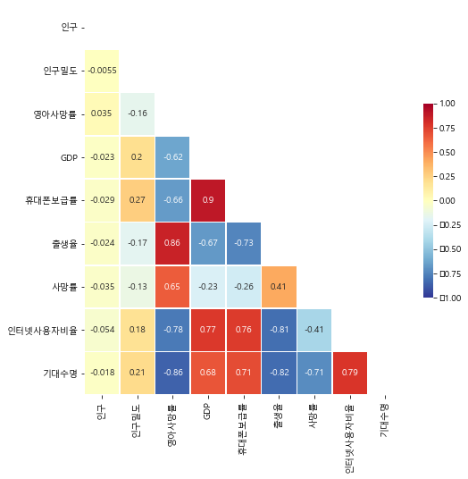

```python
fig,ax=plt.subplots(figsize=(8,8))
mask = np.zeros_like(world.corr(), dtype=np.bool)
mask[np.triu_indices_from(mask)] = True
sns.heatmap(world.corr(),
            cmap='RdYlBu_r',
            annot=True,
            mask=mask,
            linewidths=.5,
            cbar_kws={'shrink':.5},
            vmin=-1,
            vmax=1)
```

heatmap()을 통하여 연속형 변수간의 상관계수를 확인했다. 그 결과 인터넷 사용자 비율과 영아 사망률은 -0.78의 상관계수를 가진다. 이는 -0.7보다 높은 것을 보아 강한 음의 상관 관계를 가지며, **이를 통하여 대립 가설이였던 인터넷 사용자 비율이 낮은 그룹과 인터넷 사용자 비율이 높은 그룹의 영아 사망률 평균은 다르다에서 인터넷 사용자 비율이 높아질수록 영아 사망률은 낮아진다를 알 수 있다.**

그렇다면, 두 연속형 변수인 인터넷 사용자 비율과 영아 사망률 데이터의 인과 관계를 추측하기 위해 선형회귀모형을 만든다. 이를 위한 두 변수를 다음과 같이 구분한다.

| 변수 | 변수명 |
| --- | --- |
| X(독립변수) | 인터넷사용지비율 |
| Y(종속변수) | 영아사망률 |

두 변수를 이용하여 회귀 모형을 구축한다.

```python
lin_reg = sm.OLS.from_formula("영아사망률 ~ 인터넷사용자비율", world).fit()
lin_reg.summary()
```

OLS Regression Results

| Dep. Variable: | 영아사망률 | R-squared: | 0.603 |
| --- | --- | --- | --- |
| Model: | OLS | Adj. R-squared: | 0.601 |
| Method: | Least Squares | F-statistic: | 266.1 |
| Date: | Fri, 03 Jul 2020 | Prob (F-statistic): | 5.73e-37 |
| Time: | 17:27:10 | Log-Likelihood: | -807.73 |
| No. Observations: | 177 | AIC: | 1619. |
| Df Residuals: | 175 | BIC: | 1626. |
| Df Model: | 1 |  |  |
| Covariance Type: | nonrobust |  |  |

|  | coef | std err | t | P>\|t\| | [0.025 | 0.975] |
| --- | --- | --- | --- | --- | --- | --- |
| Intercept | 93.3648 | 3.806 | 24.529 | 0.000 | 85.853 | 100.877 |
| 인터넷사용자비율 | -101.6182 | 6.230 | -16.312 | 0.000 | -113.913 | -89.323 |

| Omnibus: | 50.919 | Durbin-Watson: | 1.816 |
| --- | --- | --- | --- |
| Prob(Omnibus): | 0.000 | Jarque-Bera (JB): | 144.036 |
| Skew: | 1.170 | Prob(JB): | 5.28e-32 |
| Kurtosis: | 6.749 | Cond. No. | 4.66 |

Warnings:  
[1] Standard Errors assume that the covariance matrix of the errors is correctly specified.

구축된 회귀 모형의 intercept는 93.3648이며, 인터넷 사용자 비율은 -101.6182이다. 이룰 통하여 다음과 같은 회귀 모형이 구축된다

| 영아사망률 = -101.6182 * 인터넷사용자비율 + 93.3648 |
| --- |

또한, R-squared는 0.603에 해당한다. 이는 추정한 선형 모형이 주어진 자료에 적합한 정도를 재는 척도이며, 본 회귀식은 본 데이터를 60.3% 설명이 가능하다는 의미이다. 이는 해당 회귀식이 데이터를 충분히 설명 가능한 수치이다.  
P > |t|는 독립변수의 유의확률이며 0.05 이하의 값이 되어야 독립변수가 종속변수에 영향을 미치는 것을 유의미 하다고 본다. 본 회귀식에서는 0이므로 인터넷 사용자 비율은 영아 사망률에 유의미하게 영향을 미친다고 할 수 있다.  
Durbin-Watson은 전차의 독립성을 확인할 수 있는 수치이다. 일반적으로 1.5 ~ 2.5 사이이면 독립으로 판단하고 회귀모형이 적합하다고 하는데, 본 회귀식은 1.816으로 잔차들이 자기상관을 갖지 않는 다는 의미이다.

```python
Infant_x = [i for i in np.arange(0, 1, 0.01)]
Infant_y = [-101.6182*i+93.3648 for i in np.arange(0, 1, 0.01)]
```

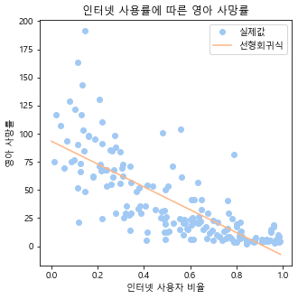

```python
plt.plot(world['인터넷사용자비율'], world['영아사망률'], 'o', label='실제값')
plt.plot(Infant_x, Infant_y, label='선형회귀식')
plt.title('인터넷 사용률에 따른 영아 사망률')
plt.xlabel('인터넷 사용자 비율')
plt.ylabel('영아 사망률')
plt.legend()
plt.show()
```

**작성한 선형 회귀식과 실제 데이터를 비교하였다. 실제로 인터넷 사용자 비율이 증가할수록 영아 사망률이 낮아지는 경향을 보이며, 이는 선형 회귀식이 데이터를 완전히 설명해주지는 못하지만, 인터넷 사용자 비율 증가에 따른 영아 사망률 감소의 경향을 훌륭히 나타내 주는 것으로 보인다. 이때 주의할 점은 인터넷 사용자 비율은 0보다 크고 1보다 작은 값이다.**

### 6. 결론 및 본인 차별화 포인트

본 데이터 분석에서는 인터넷 사용자 비율을 인터넷 인프라로 가정하고, 인터넷 사용자 비율이 기대 수명과 영아 사망률 데이터에 어느 정도 영향을 미칠지 분석하여, 인터넷 사용자 비율이 의료 서비스 수준과 의료 인프라 수준에 미치는 영향을 분석하였다. 분석 결과 인터넷 사용자 비율이 매우 낮은 나라에서는 인터넷 인프라 구축이 매우 효과적인 의료 서비스 및 의료 인프라의 향상을 제공할 수 있을 것으로 기대된다. 또한 이미 GDP와 인터넷 사용자 비율이 높은 나라에서는 더 높은 인터넷 인프라가 의료 서비스의 향상을 늘리는데 큰 효과를 얻지는 못할 것으로 예상된다. 이러한 나라들은 의료 서비스 구축을 위해 인터넷 인프라를 제외한 그 외의 분야에 투자를 하는 것이 적절해 보인다. 인터넷 사용률이 증가 할수록 영아 사망률이 낮아진다는 점은 T-분석을 통하여 증명을 하였고, 이에 대해 인터넷 사영률과 영아 사망률에 대한 선형 회귀식을 도출 하였으며, 이 선형 회귀식을 평가한 결과 해당 선형식이 인터넷 사용자 비율과 영아 사망률의 관계를 훌륭하게 나타낸다고 평가된다.

**본 데이터 분석을 위해 사용한 차별화 포인트는 다음과 같다.**

- 데이터 분석 전에 분석하고 싶은 내용을 미리 기술하고, 점점 세분화하는 방식으로 진행되도록 하였다.
- 데이터 분석이 용이하도록 변수명을 한글, 그리고 괄호와 띄어쓰기를 제거하는 과정을 하였으며, 데이터 병합에 용이하도록 각 데이터 테이블의 key에 해당하는 변수를 통일하였다.
- 데이터 병합 이전에 분석할 데이터를 정하고, 이용하지 않을 데이터를 제거하여 데이터 병합 이후에 적절한 양의 데이터를 유지하도록 하였다.
- 범주로 묶기 어렵고, 데이터 분석에 용이하지 못한 타입으로 적혀있는 범주형 데이터를 한글, 그리고 데이터 치환 과정에서 같은 대륙은 범주 하나로 묶어 그룹의 갯수를 줄였다.
- 데이터 클린징 과정에서 타당한 근거를 들어 데이터 결측치보다 데이터 이상치를 먼저 제거하였다.
- 실제 나라 데이터에서 쉽게 이상치를 파악할 수 있는 인구, 인구밀도, GDP 데이터는 정렬을 통하여 최댓값, 최솟값을 구한 후 실제 데이터와 비교 분석하여 이상치인지와 데이터를 분석에 사용할 것인지 파악하였다.
- describe()와 boxplot()은 연속형 변수의 이상치만을 볼 수 있으므로, 범주형 데이터의 이상치를 따로 분석하기 위해 value_counts() 메소드를 통하여 이상치를 관측하였다.
- 기대수명과 영아 사망률이 인터넷 사용자 비율 뿐만이 아니라 GDP에 영향을 크게 받을 것을 고려하여 인터넷 사용자 비율과 GDP를 상관분석 하였으며, 각각의 경우를 나눠 기대수명 변화 경향을 시각화하였다.
- 연속형 변수를 범주형 변수로 그룹화 하며 describe()를 통하여 그룹을 min-25%, 25%-50%, 50%-75%, 75%-max로 구분하여 각각의 범주에 같은 수의 데이터가 그룹화되도록 하였다.
- 회귀모형을 구축하고, 구축한 회귀식과 실제 데이터를 시각화하여 회귀 모형 구축이 잘 되었는지 평가하였다.